# Project Python Foundations: FoodHub Data Analysis

**Marks: 60**

### Context

The number of restaurants in New York is increasing day by day. Lots of students and busy professionals rely on those restaurants due to their hectic lifestyles. Online food delivery service is a great option for them. It provides them with good food from their favorite restaurants. A food aggregator company FoodHub offers access to multiple restaurants through a single smartphone app.

The app allows the restaurants to receive a direct online order from a customer. The app assigns a delivery person from the company to pick up the order after it is confirmed by the restaurant. The delivery person then uses the map to reach the restaurant and waits for the food package. Once the food package is handed over to the delivery person, he/she confirms the pick-up in the app and travels to the customer's location to deliver the food. The delivery person confirms the drop-off in the app after delivering the food package to the customer. The customer can rate the order in the app. The food aggregator earns money by collecting a fixed margin of the delivery order from the restaurants.

### Objective

The food aggregator company has stored the data of the different orders made by the registered customers in their online portal. They want to analyze the data to get a fair idea about the demand of different restaurants which will help them in enhancing their customer experience. Suppose you are hired as a Data Scientist in this company and the Data Science team has shared some of the key questions that need to be answered. Perform the data analysis to find answers to these questions that will help the company to improve the business.

### Data Description

The data contains the different data related to a food order. The detailed data dictionary is given below.

### Data Dictionary

- order_id: Unique ID of the order
- customer_id: ID of the customer who ordered the food
- restaurant_name: Name of the restaurant
- cuisine_type: Cuisine ordered by the customer
- cost: Cost of the order
- day_of_the_week: Indicates whether the order is placed on a weekday or weekend (The weekday is from Monday to Friday and the weekend is Saturday and Sunday)
- rating: Rating given by the customer out of 5
- food_preparation_time: Time (in minutes) taken by the restaurant to prepare the food. This is calculated by taking the difference between the timestamps of the restaurant's order confirmation and the delivery person's pick-up confirmation.
- delivery_time: Time (in minutes) taken by the delivery person to deliver the food package. This is calculated by taking the difference between the timestamps of the delivery person's pick-up confirmation and drop-off information

### Let us start by importing the required libraries

```python
import numpy as np
import pandas as pd
import matplotlib.pyplot as plt
import seaborn as sns
import mplcyberpunk
plt.style.use("cyberpunk")
```

### Understanding the structure of the data

```python
# read the data
my = pd.read_csv("C:\\_MyU 2023\\Pessoal\\Data Science Post Graduation\\Python\\Project 1\\foodhub_order.csv")
# returns the first 5 rows
my.head()
```

|  | order_id | customer_id | restaurant_name | cuisine_type | cost_of_the_order | day_of_the_week | rating | food_preparation_time | delivery_time |
| --- | --- | --- | --- | --- | --- | --- | --- | --- | --- |
| 0 | 1477147 | 337525 | Hangawi | Korean | 30.75 | Weekend | Not given | 25 | 20 |
| 1 | 1477685 | 358141 | Blue Ribbon Sushi Izakaya | Japanese | 12.08 | Weekend | Not given | 25 | 23 |
| 2 | 1477070 | 66393 | Cafe Habana | Mexican | 12.23 | Weekday | 5 | 23 | 28 |
| 3 | 1477334 | 106968 | Blue Ribbon Fried Chicken | American | 29.20 | Weekend | 3 | 25 | 15 |
| 4 | 1478249 | 76942 | Dirty Bird to Go | American | 11.59 | Weekday | 4 | 25 | 24 |

#### Observations:

The DataFrame has 9 columns as mentioned in the Data Dictionary. Data in each row corresponds to the order placed by a customer.

### **Question 1:** How many rows and columns are present in the data? [0.5 mark]

```python
print("There are", my.shape[0], 'rows and', my.shape[1], "columns.")
```

```
There are 1898 rows and 9 columns.
```

#### Observations:

Answer: There are 1898 rows and 9 columns.

### **Question 2:** What are the datatypes of the different columns in the dataset? (The info() function can be used) [0.5 mark]

```python
my.info()
```

```
<class 'pandas.core.frame.DataFrame'>
RangeIndex: 1898 entries, 0 to 1897
Data columns (total 9 columns):
 #   Column                 Non-Null Count  Dtype
---  ------                 --------------  -----
 0   order_id               1898 non-null   int64
 1   customer_id            1898 non-null   int64
 2   restaurant_name        1898 non-null   object
 3   cuisine_type           1898 non-null   object
 4   cost_of_the_order      1898 non-null   float64
 5   day_of_the_week        1898 non-null   object
 6   rating                 1898 non-null   object
 7   food_preparation_time  1898 non-null   int64
 8   delivery_time          1898 non-null   int64
dtypes: float64(1), int64(4), object(4)
memory usage: 133.6+ KB
```

#### Observations:

Answer: As a result:

- Order Id, customer Id, food preparation time and delivery time are in int datatypes;
- Restaurant name, cuisine type, day of the weed and rating are in object datatype;
- Cost of the order is in float datatype.

### **Question 3:** Are there any missing values in the data? If yes, treat them using an appropriate method. [1 mark]

```python
my.isnull().sum()
```

```
order_id                 0
customer_id              0
restaurant_name          0
cuisine_type             0
cost_of_the_order        0
day_of_the_week          0
rating                   0
food_preparation_time    0
delivery_time            0
dtype: int64
```

#### Observations:

Answer: There are no missing values.

### **Question 4:** Check the statistical summary of the data. What is the minimum, average, and maximum time it takes for food to be prepared once an order is placed? [2 marks]

```python
my['food_preparation_time'].describe().T
```

```
count    1898.000000
mean       27.371970
std         4.632481
min        20.000000
25%        23.000000
50%        27.000000
75%        31.000000
max        35.000000
Name: food_preparation_time, dtype: float64
```

#### Observations:

Answers:

- Minimum time: 20 minutes;
- Average time: 27 minutes;
- Maximum time: 35 minutes.

### **Question 5:** How many orders are not rated? [1 mark]

```python
#my['rating'].value_counts()
print(my['rating'].value_counts()['Not given'])
```

```
736
```

#### Observations:

Answer: 736 orders are not rated (not given)

### Exploratory Data Analysis (EDA)

### **Question 6:** Explore all the variables and provide observations on their distributions. (Generally, histograms, boxplots, countplots, etc. are used for univariate exploration.) [9 marks]

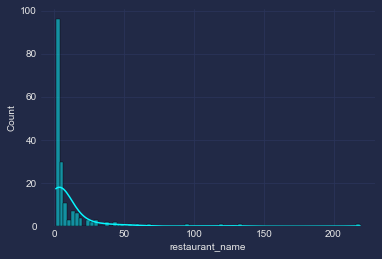

```python
# Orders Analysis (1/2)

orders_per_rest=my['restaurant_name'].value_counts()
sns.histplot(orders_per_rest, kde=True)
```

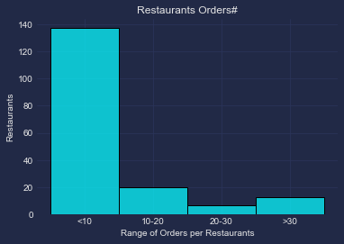

```python
# Orders Analysis (2/2)

orders_range=pd.cut(orders_per_rest,
                    bins=[0,10,20,30,200],
                    labels=['<10','10-20','20-30','>30'],right=False)
sns.histplot(orders_range)
plt.title('Restaurants Orders#')
plt.xlabel('Range of Orders per Restaurants')
plt.ylabel('Restaurants')
```

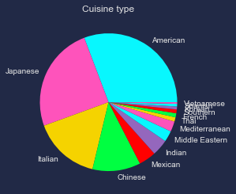

```
American          584
Japanese          470
Italian           298
Chinese           215
Mexican            77
Indian             73
Middle Eastern     49
Mediterranean      46
Thai               19
French             18
Southern           17
Korean             13
Spanish            12
Vietnamese          7
Name: cuisine_type, dtype: int64
```

```python
# Cuisine Type

food_type = my['cuisine_type'].value_counts()
labels = food_type.index.tolist()
orders = food_type.values.tolist()
plt.title('Cuisine type')
plt.pie(orders, labels=labels)
plt.show()

print(food_type)
```

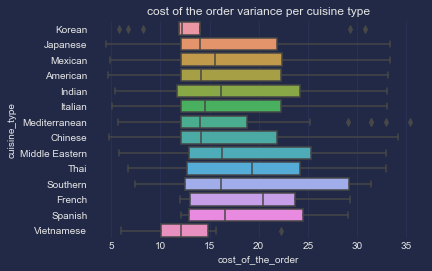

```python
# Cuisine Price
sns.boxplot(data=my, x='cost_of_the_order', y='cuisine_type')
plt.title('cost of the order variance per cuisine type')
```

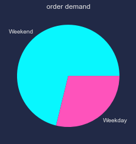

```python
# Day of the week
weekdays = my['day_of_the_week'].value_counts()
labels = weekdays.index.tolist()
days = weekdays.values.tolist()
plt.title('order demand')
plt.pie(days, labels=labels)
plt.show()
```

```
      cuisine_type  cost_of_the_order
0           French          19.793889
1         Southern          19.300588
2             Thai          19.207895
3          Spanish          18.994167
4   Middle Eastern          18.820612
5          Mexican          16.933117
6           Indian          16.919726
7          Italian          16.418691
8         American          16.319829
9          Chinese          16.305209
10        Japanese          16.304532
11   Mediterranean          15.474783
12          Korean          14.001538
13      Vietnamese          12.882857
```

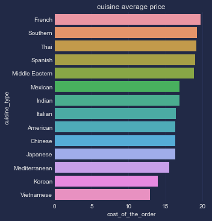

```python
# Cuisine Average Price

cuisine_price=my.groupby(['cuisine_type'])['cost_of_the_order'].mean().sort_values(ascending=False).reset_index()
sns.catplot(data=cuisine_price,y= 'cuisine_type', x='cost_of_the_order', kind='bar')
plt.title('cuisine average price')
print(cuisine_price)
```

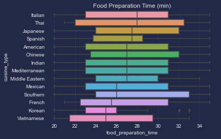

```python
# Food preparation time
sns.boxplot(data=my, x='food_preparation_time', y='cuisine_type',
            order=my.groupby('cuisine_type')['food_preparation_time']
            .median().sort_values(ascending=False).index)
plt.title('Food Preparation Time (min)')
```

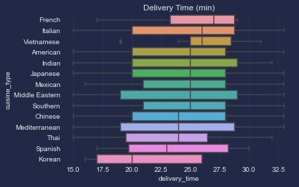

```python
# Food delivery time
sns.boxplot(data=my, x='delivery_time', y='cuisine_type',
            order=my.groupby('cuisine_type')['delivery_time']
            .median().sort_values(ascending=False).index)
plt.title('Delivery Time (min)')
```

```python
# total time
my['total_time'] = my['food_preparation_time']+my['delivery_time']
print(my.loc[:, ['total_time', 'food_preparation_time', 'delivery_time']])
```

```
      total_time  food_preparation_time  delivery_time
0             45                     25             20
1             48                     25             23
2             51                     23             28
3             40                     25             15
4             49                     25             24
...          ...                    ...            ...
1893          48                     31             17
1894          50                     31             19
1895          55                     31             24
1896          54                     23             31
1897          52                     28             24

[1898 rows x 3 columns]
```

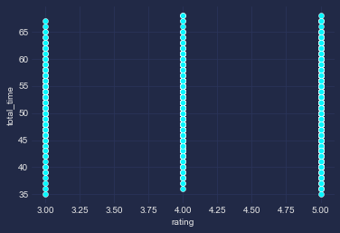

```python
# Checking any correlation between total time and rating.

my2=my.copy()
my2 = my2.drop(my2[my2['rating'] == 'Not given'].index)
my2['rating'] = my2['rating'].astype(int)
sns.scatterplot(data=my2, x='rating', y='total_time')
```

### **Question 7**: Which are the top 5 restaurants in terms of the number of orders received? [1 mark]

```python
my['restaurant_name'].value_counts().head()
```

```
Shake Shack                  219
The Meatball Shop            132
Blue Ribbon Sushi            119
Blue Ribbon Fried Chicken     96
Parm                          68
Name: restaurant_name, dtype: int64
```

### Observations:

Answer: Top 5 restaurants (amount of orders received):

- Shake Shack: 219
- The Meatball Shop: 132
- Blue Ribbon Sushi: 119
- Blue Ribbon Fried Chicken: 96
- Parm: 68

### **Question 8**: Which is the most popular cuisine on weekends? [1 mark]

```python
my['cuisine_type'][my['day_of_the_week']=='Weekend'].value_counts().head()
```

```
American    415
Japanese    335
Italian     207
Chinese     163
Mexican      53
Name: cuisine_type, dtype: int64
```

### Observations:

Answer: The most popular cuisine on weekends is American, with 415 orders received on weekends.

### **Question 9**: What percentage of the orders cost more than 20 dollars? [2 marks]

```python
more20 = len(my[my['cost_of_the_order'] > 20])
total = len(my)
result=more20/total *100
print(result)
```

```
29.24130663856691
```

#### Observations:

Answer: 29.24% of the orders cost more than 20 dollars

### **Question 10**: What is the mean order delivery time? [1 mark]

```python
my['delivery_time'].mean()
```

```
24.161749209694417
```

#### Observations:

Answer: The mean order delivery time is 24.16 minutes.

### **Question 11:** The company has decided to give 20% discount vouchers to the top 3 most frequent customers. Find the IDs of these customers and the number of orders they placed. [1 mark]

```python
my.groupby('customer_id')['order_id'].count().sort_values(ascending= False).head(3)
```

```
customer_id
52832    13
47440    10
83287     9
Name: order_id, dtype: int64
```

#### Observations:

Answer: The top 3 most frequent customers are: 1st Customer ID 52832 with 13 orders placed, 2nd Customer ID 47440 with 10 orders placed and 3rd Customer ID 83287 with 9 orders placed.

### **Question 12**: Perform a multivariate analysis to explore relationships between the important variables in the dataset. (It is a good idea to explore relations between numerical variables as well as relations between numerical and categorical variables) [10 marks]

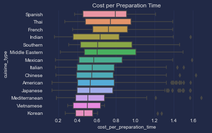

```python
my['cost_per_preparation_time']=my['cost_of_the_order']/my['food_preparation_time']
#cuisine_effective_profit = my.groupby('cuisine_type')['cost_per_preparation_time'].mean().sort_values(ascending= False)
#print(cuisine_effective_profit)

sns.boxplot(data=my, x='cost_per_preparation_time', y='cuisine_type',
            order=my.groupby('cuisine_type')['cost_per_preparation_time']
            .median().sort_values(ascending=False).index)
plt.title('Cost per Preparation Time')
```

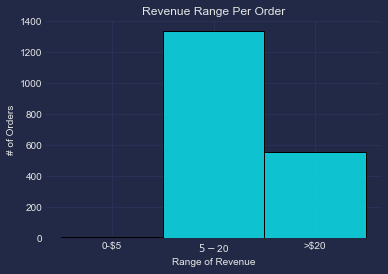

```python
tax_range=pd.cut(my['cost_of_the_order'],
                    bins=[0,5,20,200],
                    labels=['0-$5','$5-$20','>$20'],right=False)
sns.histplot(tax_range)
plt.title('Revenue Range Per Order')
plt.xlabel('Range of Revenue')
plt.ylabel('# of Orders')
```

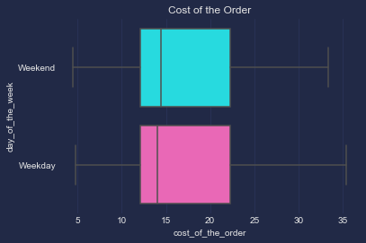

```python
sns.boxplot(data=my, x='cost_of_the_order', y='day_of_the_week')
plt.title('Cost of the Order')
```

```python
'''
price vs cuisine availability vs price per minutes spending

I see opportunities to invest in a type of cuisine where:
1) Prices are higher than average.
2) There is limited demand in the dataset, providing opportunities for growth,
cost reduction, and improved net margin.
3) There is a good price-to-time ratio for preparation, resulting in a good margin.
'''
# Good Price
average_price=my['cost_of_the_order'].mean()

# Opportunity to increase demand
cuisine_amount=food_type.to_frame()
cuisine_amount.rename(columns={'cuisine_type': 'type_count', 'Unnamed: 0':'country'}, inplace=True)
cuisine_amount.index.name = 'cuisine_type'

# Good net margin
cousine_cost=my.groupby('cuisine_type')['cost_per_preparation_time'].mean()
cousine_cost=cousine_cost.to_frame()
average_cost=my['cost_per_preparation_time'].mean()

# merging 3 dataframes in one
matrix=pd.merge(cuisine_amount, cuisine_price, on='cuisine_type')
matrix2=pd.merge(matrix,cousine_cost,on='cuisine_type')

# printing
print(matrix2)
print ('='*100)

print('Average cost_of_the_order: ',average_price)
print ('='*100)

print('Average cost_per_preparation_time: ',average_cost)
print ('='*100)

# Opportunity!
best_deal=matrix2[(matrix2['type_count'] < 100) & (matrix2['cost_of_the_order'] > average_price)&
             (matrix2['cost_per_preparation_time']>average_cost)]

best_deal.sort_values(by='cost_per_preparation_time', ascending=False)
```

```
      cuisine_type  type_count  cost_of_the_order  cost_per_preparation_time
0         American         584          16.319829                   0.613126
1         Japanese         470          16.304532                   0.607918
2          Italian         298          16.418691                   0.608368
3          Chinese         215          16.305209                   0.608599
4          Mexican          77          16.933117                   0.657455
5           Indian          73          16.919726                   0.644022
6   Middle Eastern          49          18.820612                   0.716674
7    Mediterranean          46          15.474783                   0.586371
8             Thai          19          19.207895                   0.726036
9           French          18          19.793889                   0.751007
10        Southern          17          19.300588                   0.730350
11          Korean          13          14.001538                   0.558296
12         Spanish          12          18.994167                   0.733101
13      Vietnamese           7          12.882857                   0.496204
====================================================================================================
Average cost_of_the_order:  16.498851422550054
====================================================================================================
Average cost_per_preparation_time:  0.6190275028999184
====================================================================================================
```

|  | cuisine_type | type_count | cost_of_the_order | cost_per_preparation_time |
| --- | --- | --- | --- | --- |
| 9 | French | 18 | 19.793889 | 0.751007 |
| 12 | Spanish | 12 | 18.994167 | 0.733101 |
| 10 | Southern | 17 | 19.300588 | 0.730350 |
| 8 | Thai | 19 | 19.207895 | 0.726036 |
| 6 | Middle Eastern | 49 | 18.820612 | 0.716674 |
| 4 | Mexican | 77 | 16.933117 | 0.657455 |
| 5 | Indian | 73 | 16.919726 | 0.644022 |

### **Question 13:** The company wants to provide a promotional offer in the advertisement of the restaurants. The condition to get the offer is that the restaurants must have a rating count of more than 50 and the average rating should be greater than 4. Find the restaurants fulfilling the criteria to get the promotional offer. [3 marks]

```python
rest_count = my2.groupby('restaurant_name')['rating'].count().sort_values(ascending= False)
#print(rest_count)

rest_rating = my2.groupby('restaurant_name')['rating'].mean().sort_values(ascending= False)
#print(rest_rating)

rating_df = pd.merge(rest_count, rest_rating, on='restaurant_name')
rating_df.columns=['Amount of rating','Rating average']
question_answer = rating_df.loc[rating_df['Amount of rating'] > 50, 'Rating average'] > 4
print(question_answer)
```

```
restaurant_name
Shake Shack                  True
The Meatball Shop            True
Blue Ribbon Sushi            True
Blue Ribbon Fried Chicken    True
Name: Rating average, dtype: bool
```

#### Observations:

Answer: Following the restaurants that fulfilling the criteria to get the promotional offer:

- Shake Shack
- The Meatball Shop
- Blue Ribbon Sushi
- Blue Ribbon Fried Chicken

### **Question 14:** The company charges the restaurant 25% on the orders having cost greater than 20 dollars and 15% on the orders having cost greater than 5 dollars. Find the net revenue generated by the company across all orders. [3 marks]

```python
def charges(price):
    if price > 20:
        return price * 0.25
    elif price > 5:
        return price * 0.15
    else:
        return price*0

my['charges'] = my['cost_of_the_order'].apply(charges)
my['restaurant_net_revenue']=my['cost_of_the_order']-my['charges']

print('The company net revenue is ',my['charges'].sum())
```

```
The company net revenue is  6166.303
```

#### Observations:

Answer: The company net revenue is 6166.30 dollars.

### **Question 15:** The company wants to analyze the total time required to deliver the food. What percentage of orders take more than 60 minutes to get delivered from the time the order is placed? (The food has to be prepared and then delivered.) [2 marks]

```python
total_orders=len(my)
orders_more_than_60m=len(my[my['total_time']>60])
answer_Q15=orders_more_than_60m/total_orders*100
print('Orders more than 60m :',orders_more_than_60m)
print('Total orders:',total_orders)
print('Percentage of orders take more than 60 minutes to get delivered from the time the order is placed:',answer_Q15,'%')
```

```
Orders more than 60m : 200
Total orders: 1898
Percentage of orders take more than 60 minutes to get delivered from the time the order is placed: 10.537407797681771 %
```

#### Observations:

Answer: Percentage of orders take more than 60 minutes to get delivered from the time the order is placed: 10.53 %

### **Question 16:** The company wants to analyze the delivery time of the orders on weekdays and weekends. How does the mean delivery time vary during weekdays and weekends? [2 marks]

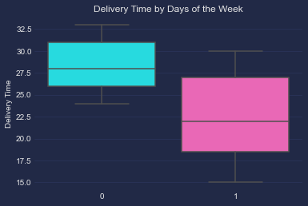

```
Weekday orders: 547 -> 28.8%
Weekend orders: 1351 -> 71.2%
```

```python
weekday_dt= my['delivery_time'][my['day_of_the_week']=='Weekday']
weekend_dt = my['delivery_time'][my['day_of_the_week']=='Weekend']

sns.boxplot(data=[weekday_dt, weekend_dt])
plt.ylabel('Delivery Time')
plt.title('Delivery Time by Days of the Week')
plt.show()

weekday_dt_len=len(weekday_dt)

weekday_ord= len(my['order_id'][my['day_of_the_week']=='Weekday'])
print('Weekday orders:',weekday_ord,("-> {:.1%}".format(weekday_ord/total_orders)))
print('Weekend orders:',weekend_ord,("-> {:.1%}".format(weekend_ord/total_orders)))
```

```python
weekday_food= my['food_preparation_time'][my['day_of_the_week']=='Weekday'].mean()
weekday_delivery= my['delivery_time'][my['day_of_the_week']=='Weekday'].mean()

weekend_food= my['food_preparation_time'][my['day_of_the_week']=='Weekend'].mean()
weekend_delivery= my['delivery_time'][my['day_of_the_week']=='Weekend'].mean()

weekday_rating= my2['rating'][my2['day_of_the_week']=='Weekday'].mean()
weekend_rating= my2['rating'][my2['day_of_the_week']=='Weekend'].mean()


time= pd.DataFrame({'weekday':[weekday_ord,weekday_food,weekday_delivery,weekday_food+weekday_delivery,weekday_rating],
                    'weekend':[weekend_ord,weekend_food,weekend_delivery,weekend_food+weekend_delivery,weekend_rating]},
                    index=['# of Orders','Food Preparation Time (min)',
                           'Delivery Time (min)','TOTAL TIME (min)','Rating'])
print(time)
```

```
                                weekday      weekend
# of Orders                  547.000000  1351.000000
Food Preparation Time (min)   27.212066    27.436714
Delivery Time (min)           28.340037    22.470022
TOTAL TIME (min)              55.552102    49.906736
Rating                         4.308824     4.358881
```

#### Observations:

Answer in the following box (Conclusion and Recommendation)

### Conclusion and Recommendations

The volume of orders is much higher during the weekends. Nevertheless, the time of food preparation is very similar between weekdays and weekends, so the kitchen team is well dimensioned, probably with more resources available during the weekends. However, the delivery time is on average 6 minutes slower during weekdays, even with lower volume. Maybe that is the reason for worse evaluation during the weekdays. The recommendation is to invest in delivery service/resources during the weekdays.

### **Question 17:** What are your conclusions from the analysis? What recommendations would you like to share to help improve the business? (You can use cuisine type and feedback ratings to drive your business recommendations.) [6 marks]

### Conclusions:

The volume of orders is significantly higher during the weekends compared to weekdays, but the time required for food preparation remains relatively similar. The rating during the weekend is slightly better than weekdays, which could be due to faster delivery time. This provides opportunities for improvement, such as focusing on cuisine_types that generate more revenue per order than others, as this could increase net margins due to the shorter time required to prepare them. Additionally, as certain cuisine_types are less popular than others, there is an opportunity to grow and expand these offerings, which could potentially bring in more customers and further increase revenue.

### Recommendations:

In order to maximize revenue, we should invest in:

Improving delivery time during weekdays, in order to improve customer rating, as demonstrated in comparison with weekends.

Launching a targeted marketing campaign for French, Spanish, Southern, Thai, and Middle Eastern cuisines. This decision should be based on criteria such as order prices being more expensive than average, few orders presenting an evident opportunity to grow and reduce fixed costs (improve net income), and good price per time to prepare (to ensure a good net margin).

Additionally, our tax ranges should remain consistent in order to avoid any unnecessary conflicts with restaurant owners.

```python
my.to_csv('C:\\_MyU 2023\\Pessoal\\Data Science Post Graduation\\Python\\Project 1\\my_project1revC.csv',index=False)
```